# kommunrapport_master

[figure not shown]

Norberg

Kommunrapport

Resultat från undersökningen  
Liv & hälsa ung 2026

Framtagen av ledningsstabens analysenhet vid Regionala utvecklingsförvaltningen, Region Västmanland

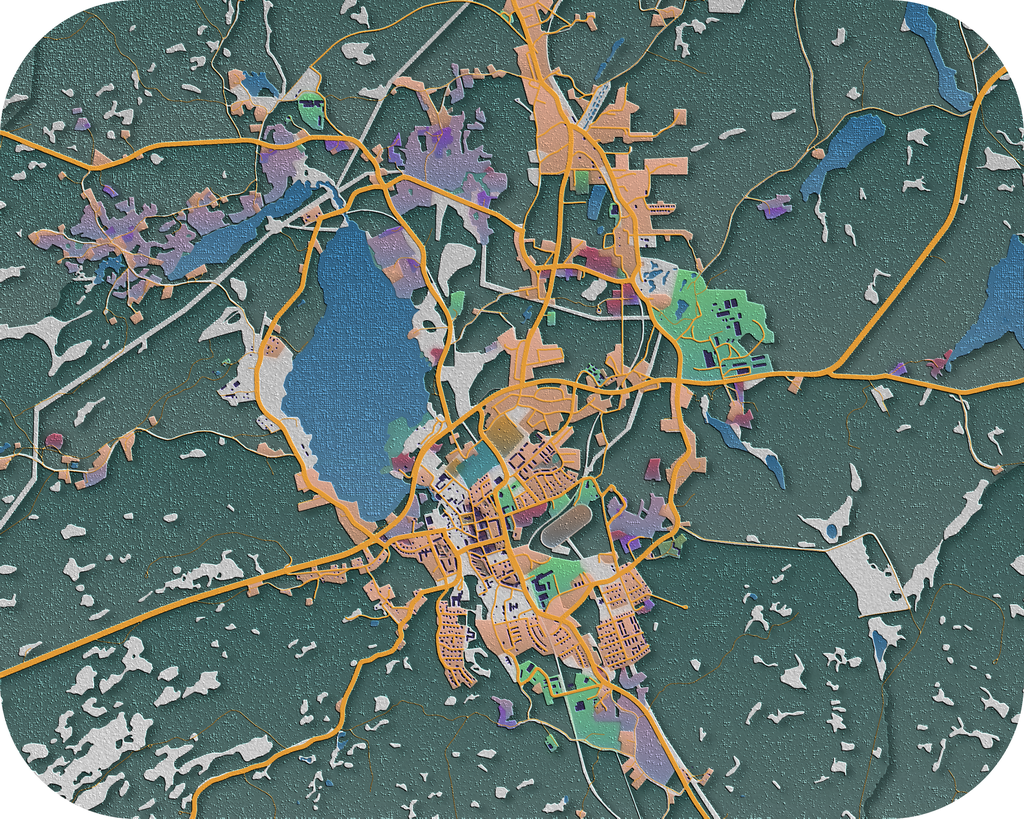

# Rapporten

Rapporten bygger på resultat från undersökningen *Liv & hälsa ung 2026*. Mer information om undersökningen finns i kapitlet **Om undersökningen**.

## Syfte

Syftet med rapporten är att ge Norberg kommun en överskådlig bild av hur kommunens resultat från undersökningen Liv & hälsa ung förhåller sig till länssnittet inom olika områden. Rapporten är uppbyggd så att varje område först presenteras med ett sammanvägt indexvärde för området, följt av en nedbrytning i de enskilda indikatorer som indexet bygger på. På så sätt blir det möjligt att inte bara se det övergripande läget, utan också identifiera vad som driver resultatet och om det finns skillnader mellan killar och tjejer.

Rapporten kompletteras med en sambandsanalys som visar vilka områden och indikatorer som har störst betydelse för ungas mående. Sammantaget utgör rapporten ett underlag för att identifiera centrala utmaningar och prioritera insatser riktade till barn och unga i Norberg .

## Metod

### Index

För beräkningen av delindexen används i första hand indikatorernas fullständiga svarsskalor, förutsatt att skalan enhetligt följer samma värderiktning. I de fall där den ursprungliga svarsskalan inte uppfyller detta krav, exempelvis där olika svarsalternativ representerar skilda situationer snarare än en graderad skala, används istället meningsfulla gruppindelningar som säkerställer en konsekvent värderiktning.

Varje indikator kodas om till skalan 0–10 och bidrar därefter med lika stor vikt till det delindex (område) den tillhör, oavsett hur många svarsalternativ eller grupper den ursprungligen består av. Delindexet beräknas som medelvärdet av de ingående indikatorerna och hamnar därmed alltid inom intervallet 0–10, vilket möjliggör jämförelser mellan områden.

Urvalet av indikatorer och konstruktionen av delindex har baserats på en kombination av statistiska analyser och konceptuella bedömningar. För varje delindex har vi undersökt om indikatorerna faktiskt mäter samma sak och hänger ihop med varandra på ett meningsfullt sätt, med hjälp av Cronbachs alfa (ett mått på intern konsistens) och principalkomponentanalys (PCA, en metod för att identifiera underliggande dimensioner i data). Indikatorer som visade sig mäta något i grunden annorlunda än övriga i ett index har prövats i andra index eller exkluderats. I de fall där ett område är brett och täcker flera delvis oberoende aspekter, som livsstil eller levnadsvillkor, har vi accepterat en lägre statistisk sammanhållning när indikatorerna ändå bedömts konceptuellt relevanta och viktiga för kommunernas beslutsunderlag.

### Områdenas innehåll

- **Utsatthet** – erfarenheter av diskriminering, trakasserier, utfrysning, hot, våld och rån.
- **Trygghet** – upplevd trygghet i bostadsområdet, skolan, på allmän plats och vid fritidsaktiviteter.
- **Tillit och förtroende** – tillit till andra människor samt förtroende för kommunen, polisen och skolan.
- **Studiegång och resultat** – skolresultat och skolfrånvaro, exempelvis underkända betyg och skolk.
- **Socialt stöd och ensamhet** – ensamhet, vänskapsrelationer och tillgång till någon att prata med och få stöd av.
- **Skolmiljö och stöd** – trivsel, studiero, stöd i skolarbetet samt relationen till och bemötandet från lärare.
- **Samhällssyn** – syn på människors lika rättigheter, våld och skadegörelse samt tillit till nyhetsmedier.
- **Livsstil** – skärmtid, sömn, matvanor, träning och fysisk aktivitet.
- **Levnadsvillkor** – familjens ekonomiska och materiella förutsättningar samt förutsättningar för studier i hemmet.
- **Hälsoförutsättningar och riskfaktorer** – stress, självskadebeteende, problematisk användning av digitala medier, sömnproblem och framtidstro.
- **Hälsa** – allmänt mående, psykiskt välbefinnande och psykisk påfrestning.
- **Föräldrarelation** – relationen till föräldrar, upplevt stöd och tillit samt föräldrarnas regler och gränssättning.
- **Fritid** – föreningsdeltagande, organiserade fritidsaktiviteter, möjlighet att delta och nöjdhet med fritiden.
- **Delaktighet** – olika former av samhälls- och politiskt deltagande, såsom diskussioner, kontakter med beslutsfattare och demonstrationer.
- **ANTS** – alkohol, narkotika, tobak och nikotin samt spel om pengar.

### Områdena i ett strukturellt sammanhang

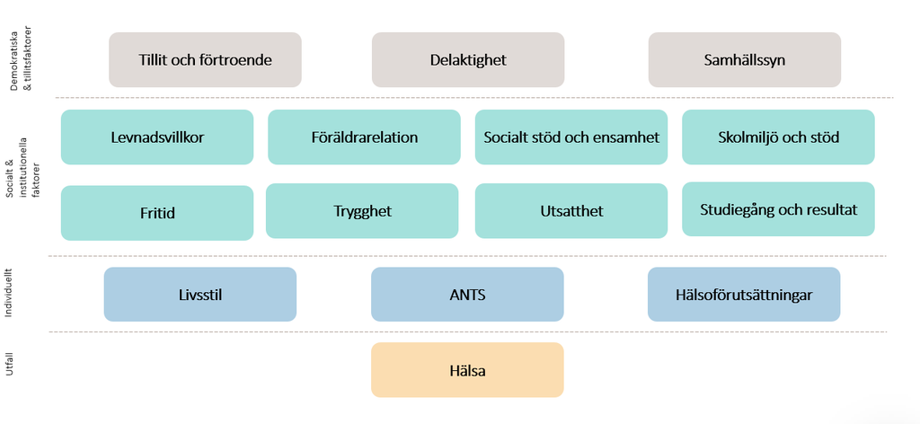

Bilden illustrerar en schematisk bild över hur rapportens områden förhåller sig till olika strukturella nivåer. Strukturen är inspirerad av Dahlgren och Whiteheads modell för hälsans bestämningsfaktorer (1991), men är anpassad utifrån de indikatorer och områden som faktiskt mäts i Liv och hälsa ung.

Modellen är ett analytiskt och pedagogiskt verktyg för att strukturera rapportens områden utifrån hur nära de ligger ungas vardag och hälsa. Den beskriver inte en exakt orsakskedja, i verkligheten samspelar områdena och många samband är ömsesidiga. Exempelvis kan hälsa påverka skolresultat, samtidigt som skolresultat kan påverka hälsa. Modellen belyser därför att olika områden kan påverkas genom insatser på olika nivåer och över olika långa tidsperspektiv.

Demokratiska och tillitsfaktorer utgör det yttersta lagret och inkluderar tillit och förtroende, delaktighet samt samhällssyn. Tillit och förtroende omfattar både mellanmänsklig tillit och förtroende för myndigheter och institutioner som skola, polis och kommun, faktorer som i stor usträckning formas av samhällsutvecklingen i stort. Delaktighet i samhällsfrågor påverkas förvisso av faktorer på lägre nivåer, som socialt stöd och individuella förutsättningar, men bedöms ändå tillhöra denna nivå eftersom graden av delaktighet också speglar hur samhällets strukturer möjliggör eller begränsar ungas inflytande. På liknande sätt påverkas samhällssynen, hur unga ser på frågor om mänskliga rättigheter, våld och medier, av normer och värderingar i det omgivande samhället.

Sociala och institutionella faktorer innefattar relationer och stöd från familj och vänner, men också faktorer kopplade till skolan som miljö, relationer och stöd från lärare. Hit hör även familjens socioekonomiska situation och de materiella levnadsvillkor den skapar, upplevd trygghet på olika platser samt erfarenheter av våld, hot och utsatthet. Fritid bedöms också vara en social och institutionell faktor, eftersom ungas möjligheter att delta i fritidsaktiviteter i hög grad formas av tillgång till arenor, ekonomiska förutsättningar och lokalt utbud, snarare än enbart individuella val. Hit hör även studiegång och resultat. Skolprestationer kan betraktas som ett utfall i sig då studieresultat följer samma sociala gradient som hälsa och påverkas i hög grad av samma underliggande faktorer. I den här rapporten är dock hälsa det primära utfallet, och studiegång och resultat behandlas därför som en av de faktorer som samvarierar med och kan bidra till att förklara ungas hälsa och välbefinnande. Placeringen motiveras också av det nära sambandet med skolmiljö och stöd.

Individuella faktorer innefattar livsstil, ANTS samt hälsoförutsättningar. Dessa faktorer speglar beteenden, vanor och riskfaktorer som i sin tur påverkas av de strukturella och sociala nivåerna ovanför.

Hälsa (allmänt månede) är utfallet för rapportens sambandsanalyser.

## Hur man läser rapporten

### Index

Delindexen visar kommunens sammanvägda resultat inom respektive område, baserat på de indikatorer som området består av. Indexvärdena rör sig mellan 0 och 10.

För samtliga områden gäller att ett högre indexvärde är mer önskvärt. Det innebär att ett högt värde på ANTS och Utsatthet speglar låg förekomst av ANTS-användning respektive låg grad av utsatthet, indikatorerna är inverterade innan indexberäkningen för att säkerställa en konsekvent värderiktning genom hela rapporten.

I den övergripande sammanfattningen av kommunens resultat används en gräns på ±0,2 indexenheter för att avgöra om ett område avviker meningsfullt från länssnittet. Gränsen baseras på den genomsnittliga variationen mellan kommuner i länet, där den typiska avvikelsen ligger på 0,10–0,20 indexenheter. Avvikelser under denna gräns bedöms som normal variation, medan avvikelser över 0,2 indexenheter lyfts fram som områden där kommunen sticker ut i förhållande till länet.

De områden och indikatorer som ingår i rapporten har valts ut för att vara så avgränsade och mätbara som möjligt, samtidigt som de tillsammans ger en tillräckligt bred bild av faktorer som är relevanta för ungas hälsa och välbefinnande. En grundläggande utgångspunkt i urvalet är att de flesta områden speglar förhållanden som går att påverka genom insatser från kommuner, skolor och andra aktörer som möter unga i vardagen.

Det är också viktigt att komma ihåg att områdena hänger ihop och kan påverka varandra. Möjligheten att påverka varierar. Inom vissa områden kan insatser ge resultat snabbare, medan andra förändras långsammare och kan påverkas mer av bredare samhällsfaktorer.

### Indikatorer

De enskilda indikatorerna presenteras som dikotomiserade andelar i resultatredovisningen, det vill säga andelen respondenter som tillhör en given grupp, exempelvis andelen som uppger god hälsa eller andelen som känner sig trygga. Detta görs för att underlätta läsbarheten och göra resultaten tillgängliga för en bred målgrupp. Till skillnad från indexvärdena redovisas enskilda indikatorer i frågans ursprungliga riktning. En hög andel kan därför innebära både en bättre situation, som hög andel trygga, och en sämre, som hög andel utsatta.

Det är värt att notera att dikotomiseringen enbart används i den deskriptiva resultatredovisningen. För beräkningen av delindexen används indikatorernas fullständiga svarsskalor eller gruppindelningar, i enlighet med vad som beskrivs ovan. En fullständig förteckning över samtliga frågor, ursprungliga svarsalternativ och hur de kodats i resultatredovisningen finns i Bilaga D – Variabellista.

### Diagram

I diagram i rapportens resultatredovisning gäller följande färgmarkeringar:

**För delindex:**

|  | Färg |
| --- | --- |
| Norberg |  |
| Länssnittet |  |

**För indikatorer:**

|  | Norberg | Län |
| --- | --- | --- |
| Kille |  |  |
| Tjej |  |  |
| Totalt |  |  |

# Att använda rapporten som underlag för prioritering

Rapporten ger underlag för prioritering på två sätt. Det första är kommunens egna resultat, på både områdes- och indikatornivå, som visar var unga i kommunen rapporterar mindre gynnsamt resultat än länssnittet. Det andra är sambandsanalysen, som visar vilka områden och indikatorer som har starkast samband med ungas allmänna mående i länet som helhet.

Med dessa två perspektiv kan kommunen identifiera områden där resultaten är sämre än länssnittet och där sambandet med mående samtidigt är starkt. Det ger ett kunskapsunderlag för att prioritera insatser inom områden som både framgår som utvecklingsområden i den egna kommunen och har starka samband med ungas mående.

Sambandsanalysen är densamma i samtliga kommunrapporter och utgör ett gemensamt analytiskt underlag, medan resultatdelen är specifik för varje kommun.

Jämförelsen med länssnittet är ett stöd för prioritering, men bör inte tolkas som ett mått på vad som är ett tillfredsställande resultat. På flera områden finns utvecklingsbehov även på länsnivå, vilket innebär att även resultat i nivå med eller över länssnittet kan motivera fortsatta insatser.

# Deltagande och svarsfrekvens

I Norberg var det 119 elever som utgjorde elevantalet i deltagande skolor, med en svarsfrekvens på 33%. Eleverna i Norberg utgör 1% av det totala urvalet i länet.

# Övergripande resultat

## Kommunindex

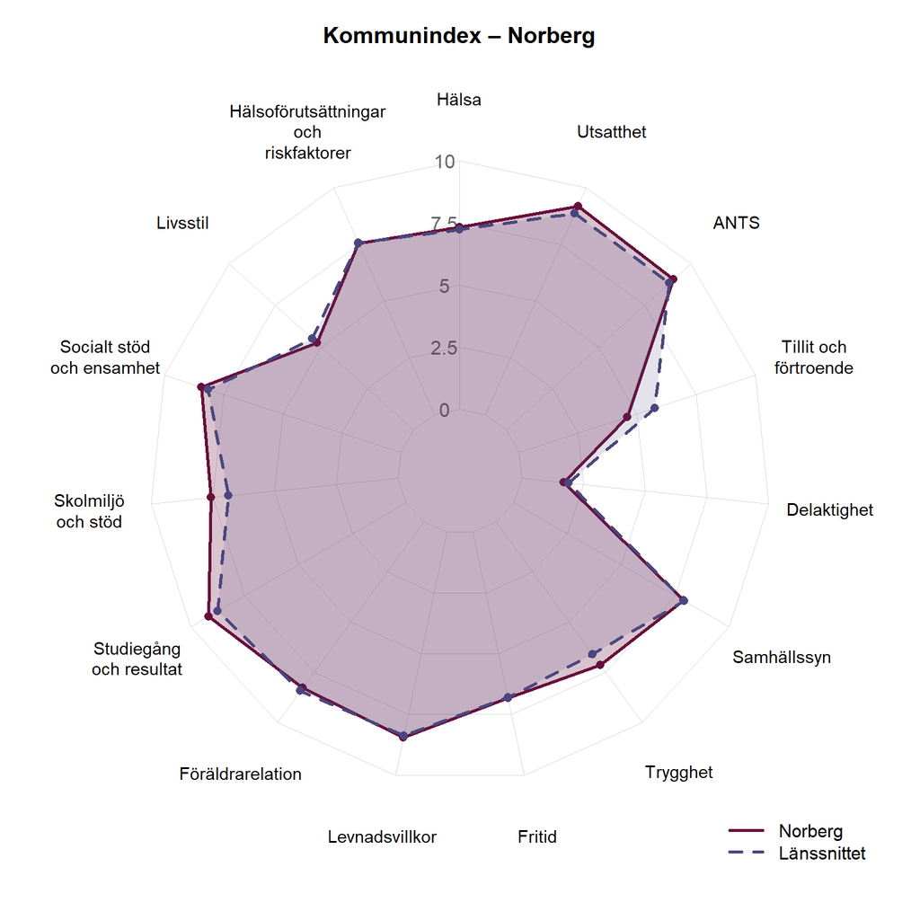

Diagram 1. Indexvärden per område jämfört med länssnittet.

Tabell 1. Kommunens indexvärden per område jämfört med länssnittet, sorterat efter avvikelse.

| Område | Kommunvärde | Länssnittet | Avvikelse |
| --- | --- | --- | --- |
| Tillit och förtroende | 4.58 | 5.74 | -1.16 |
| Skolmiljö och stöd | 7.57 | 6.88 | 0.69 |
| Trygghet | 7.13 | 6.59 | 0.54 |
| Studiegång och resultat | 9.17 | 8.75 | 0.42 |
| Utsatthet | 9.18 | 8.87 | 0.31 |
| Socialt stöd och ensamhet | 8.44 | 8.17 | 0.27 |
| Livsstil | 5.25 | 5.49 | -0.24 |
| ANTS | 9.07 | 8.84 | 0.23 |
| Delaktighet | 1.71 | 1.90 | -0.19 |
| Föräldrarelation | 8.27 | 8.41 | -0.14 |
| Hälsa | 7.33 | 7.22 | 0.11 |
| Levnadsvillkor | 8.45 | 8.37 | 0.08 |
| Samhällssyn | 7.89 | 7.93 | -0.04 |
| Fritid | 6.82 | 6.79 | 0.03 |
| Hälsoförutsättningar och riskfaktorer | 7.55 | 7.56 | -0.01 |

För Norberg framgår ett mer gynnsamt resultat än länsgenomsnittet på områdena Skolmiljö och stöd, Trygghet, Studiegång och resultat, Utsatthet, Socialt stöd och ensamhet, ANTS. Det innebär att det sammanvägda indexvärdet för dessa områden överstiger länssnittet, vilket speglar att en större andel av unga i kommunen uppvisar positiva utfall på de indikatorer som bygger upp respektive område.

För Norberg framgår ett mindre gynnsamt resultat än länsgenomsnittet på områdena Tillit och förtroende, Livsstil. Det innebär att det inom dessa områden finns ett relativt sett större behov av insatser riktade till unga i Norberg.

För Norberg ligger områdena Hälsa, Hälsoförutsättningar och riskfaktorer, Föräldrarelation, Levnadsvillkor, Fritid, Samhällssyn, Delaktighet nära länssnittet, vilket tyder på att kommunen i stora drag följer det länsövergripande mönstret inom dessa områden.

# Resultat per område

Under respektive område redovisas dels ett sammanvägt indexvärde, dels resultaten för de enskilda indikatorerna som indexet bygger på. Indexvärdet ger en övergripande bild av läget inom området, medan indikatorerna visar vad som driver resultatet och om det finns skillnader mellan killar och tjejer.

## Hälsa

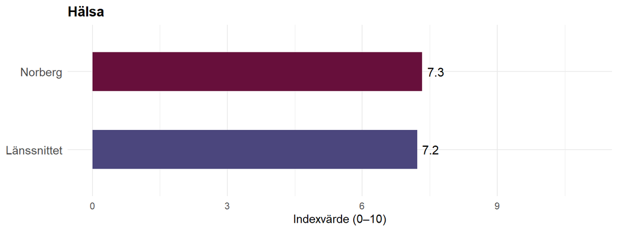

Diagram 2. Indexvärde för Hälsa jämfört med länssnittet.

Resultatet för Norberg visar en nivå i linje med länsgenomsnittet på området Hälsa (7.3 jämfört med 7.2), vilket innebär att kommunen följer det övergripande mönstret i länet.

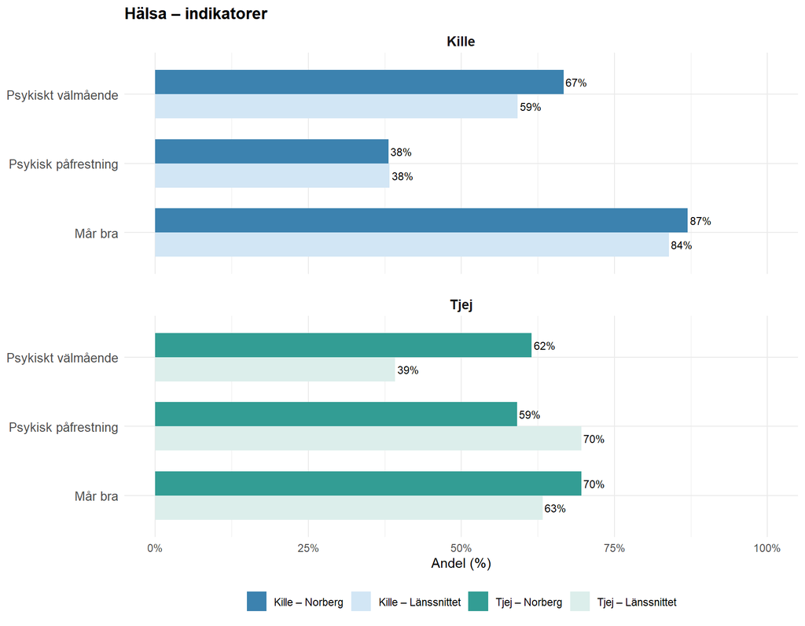

Diagram 3. Indikatorer inom Hälsa - andel per kön jämfört med länssnittet

Tabell 2. Indikatorer inom Hälsa – kommunens värde jämfört med länssnittet.

| Indikator | Kommun (%) | Länssnittet (%) | ± % | Jämfört med länet |
| --- | --- | --- | --- | --- |
| Psykiskt välmående | 64 | 49 | 15 | ▲ Högre |
| Psykisk påfrestning | 49 | 54 | -5 | ▼ Lägre |
| Mår bra | 78 | 74 | 5 | ▲ Högre |

För området Hälsa ligger Norbergs samlade resultat i linje med länets genomsnitt, men på indikatornivå framträder vissa skillnader, främst bland tjejer. Andelen tjejer med gott psykiskt välmående är 23 procentenheter högre i Norberg än i länet, och andelen med psykisk påfrestning är 11 procentenheter lägre. Även andelen tjejer som mår bra är något högre än i länet. Bland killar är andelen med gott psykiskt välmående 8 procentenheter högre än i länet, medan övriga indikatorer ligger nära länsnivån. Skillnaderna mellan tjejer och killar är därmed mindre i Norberg än i länet. Med tanke på den låga svarsfrekvensen bör resultaten tolkas med försiktighet (se avsnittet Deltagande och svarsfrekvens).

## Utsatthet

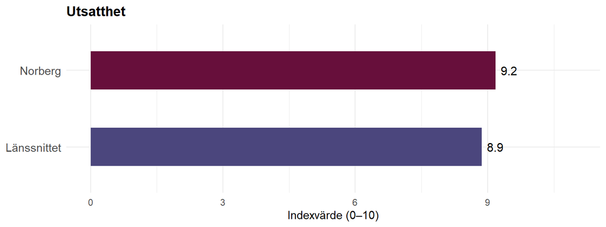

Diagram 4. Indexvärde för Utsatthet jämfört med länssnittet.

Resultatet för Norberg visar en mer gynnsam nivå på området Utsatthet jämfört med länsgenomsnittet (9.2 jämfört med 8.9), vilket tyder på att kommunen överlag har mer gynnsamma utfall för de indikatorer som ingår i området.

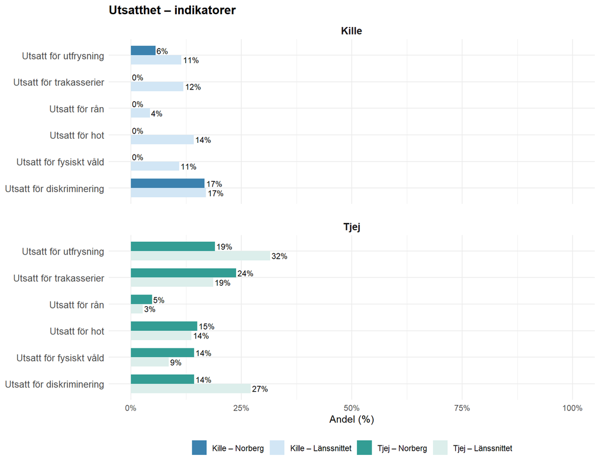

Diagram 5. Indikatorer inom Utsatthet - andel per kön jämfört med länssnittet

Tabell 3. Indikatorer inom Utsatthet – kommunens värde jämfört med länssnittet.

| Indikator | Kommun (%) | Länssnittet (%) | ± % | Jämfört med länet |
| --- | --- | --- | --- | --- |
| Utsatt för utfrysning | 13 | 22 | -9 | ▼ Lägre |
| Utsatt för diskriminering | 15 | 22 | -7 | ▼ Lägre |
| Utsatt för hot | 8 | 14 | -6 | ▼ Lägre |
| Utsatt för trakasserier | 13 | 15 | -2 | ▼ Lägre |
| Utsatt för fysiskt våld | 8 | 10 | -2 | ▼ Lägre |
| Utsatt för rån | 3 | 3 | -1 | ▼ Lägre |

Det gynnsamma resultatet för området Utsatthet förklaras främst av killarnas resultat. Bland killar i Norberg är utsattheten lägre än i länet på i stort sett samtliga indikatorer, och 0 % av killarna uppger att de utsatts för trakasserier, hot, rån eller fysiskt våld. Bland tjejer är bilden mer blandad. Andelen som utsatts för utfrysning och diskriminering är 13 procentenheter lägre än bland tjejer i länet, samtidigt som andelen som utsatts för fysiskt våld och trakasserier är 5 procentenheter högre. Med tanke på den låga svarsfrekvensen bör resultaten tolkas med försiktighet (se avsnittet Deltagande och svarsfrekvens).

## ANTS

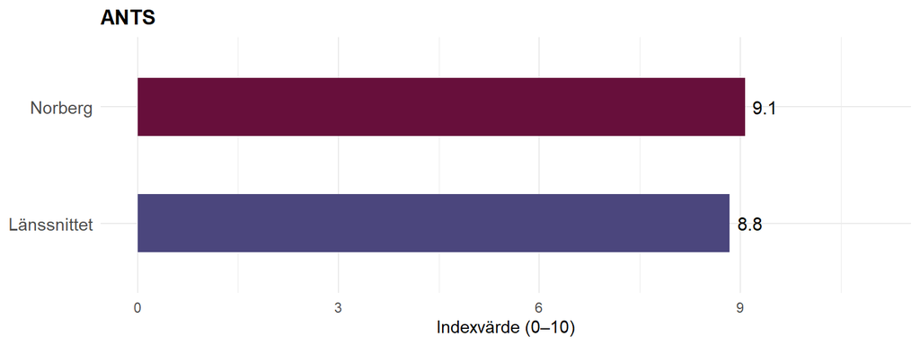

Diagram 6. Indexvärde för ANTS jämfört med länssnittet.

Resultatet för Norberg visar en mer gynnsam nivå på området ANTS jämfört med länsgenomsnittet (9.1 jämfört med 8.8), vilket tyder på att kommunen överlag har mer gynnsamma utfall för de indikatorer som ingår i området.

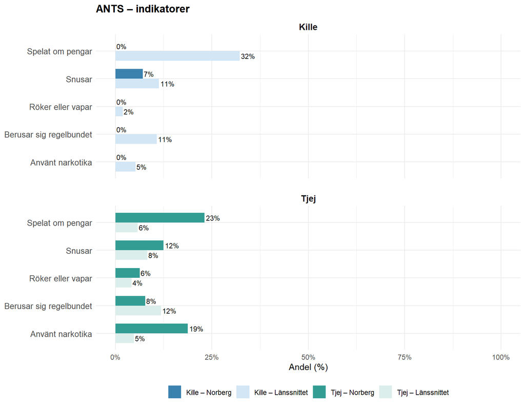

Diagram 7. Indikatorer inom ANTS - andel per kön jämfört med länssnittet

Tabell 4. Indikatorer inom ANTS – kommunens värde jämfört med länssnittet.

| Indikator | Kommun (%) | Länssnittet (%) | ± % | Jämfört med länet |
| --- | --- | --- | --- | --- |
| Berusar sig regelbundet | 4 | 11 | -8 | ▼ Lägre |
| Använt narkotika | 10 | 5 | 5 | ▲ Högre |
| Spelat om pengar | 14 | 19 | -5 | ▼ Lägre |
| Röker eller vapar | 3 | 3 | 0 | ▲ Högre |
| Snusar | 10 | 10 | 0 | ▲ Högre |

Norberg har övergripande ett mer gynnsamt resultat inom ANTS-området jämfört med länet. Det förklaras främst av killarnas resultat, medan resultaten bland tjejer skiljer sig från länet på flera indikatorer. Bland killar i Norberg är andelen som använder någon produktkategori inom ANTS lägre än i länet på samtliga indikatorer, och 0 % av killarna uppger att de spelat om pengar, berusar sig regelbundet, röker eller vapar eller har använt narkotika. Bland tjejerna i kommunen är andelen som har använt narkotika nästan fyra gånger så hög som bland tjejer i länet och andelen som spelat om pengar är 17 procentenheter högre. Även snusning är något vanligare bland tjejer i Norberg, medan andelen som berusar sig regelbundet är lägre än i länet. Med tanke på den låga svarsfrekvensen bör resultaten tolkas med försiktighet (se avsnittet Deltagande och svarsfrekvens).

## Tillit och förtroende

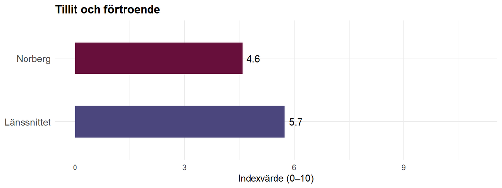

Diagram 8. Indexvärde för Tillit och förtroende jämfört med länssnittet.

Resultatet för Norberg visar en mindre gynnsam nivå på området Tillit och förtroende jämfört med länsgenomsnittet (4.6 jämfört med 5.7), vilket tyder på att kommunen överlag har mindre gynnsamma utfall för de indikatorer som ingår i området.

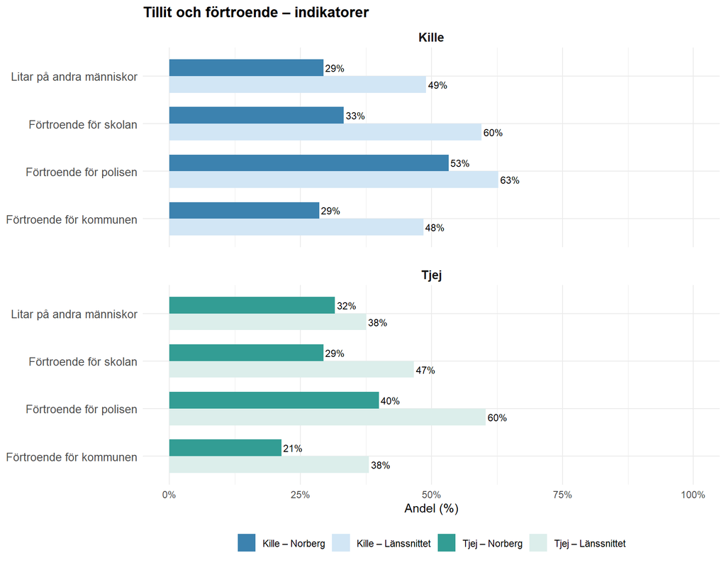

Diagram 9. Indikatorer inom Tillit och förtroende - andel per kön jämfört med länssnittet

Tabell 5. Indikatorer inom Tillit och förtroende – kommunens värde jämfört med länssnittet.

| Indikator | Kommun (%) | Länssnittet (%) | ± % | Jämfört med länet |
| --- | --- | --- | --- | --- |
| Förtroende för skolan | 31 | 53 | -22 | ▼ Lägre |
| Förtroende för kommunen | 25 | 43 | -18 | ▼ Lägre |
| Förtroende för polisen | 47 | 62 | -15 | ▼ Lägre |
| Litar på andra människor | 31 | 43 | -13 | ▼ Lägre |

Det mindre gynnsamma resultatet för området Tillit och förtroende speglar ett genomgående mönster, där samtliga indikatorer ligger under länets nivå för både tjejer och killar. Den största skillnaden gäller förtroende för skolan, som är 22 procentenheter lägre än i länet. Bland killar är förtroendet för skolan 27 procentenheter lägre än bland killar i länet, och andelen som litar på andra människor och har förtroende för kommunen är omkring 20 procentenheter lägre. Bland tjejer är skillnaderna störst för förtroende för polisen, skolan och kommunen, som ligger 17–20 procentenheter under länet. I länet har killar genomgående högre tillit och förtroende än tjejer, men i Norberg är könsskillnaderna små, eftersom killarnas resultat ligger särskilt långt under länsnivån. Med tanke på den låga svarsfrekvensen bör resultaten tolkas med försiktighet (se avsnittet Deltagande och svarsfrekvens).

## Delaktighet

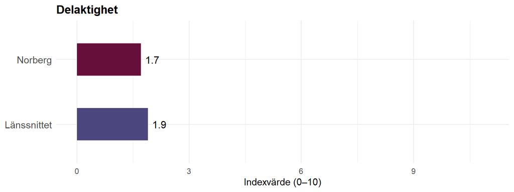

Diagram 10. Indexvärde för Delaktighet jämfört med länssnittet.

Resultatet för Norberg visar en nivå i linje med länsgenomsnittet på området Delaktighet (1.7 jämfört med 1.9), vilket innebär att kommunen följer det övergripande mönstret i länet.

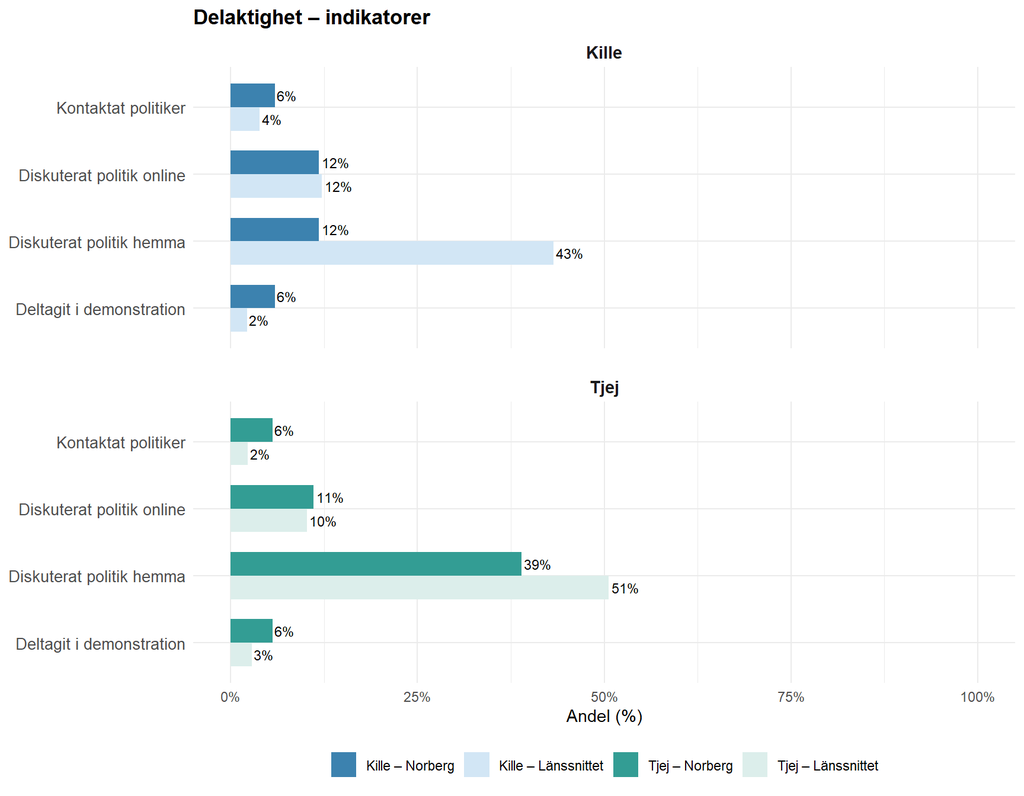

Diagram 11. Indikatatorer inom Delaktighet - andel per kön jämfört med länssnittet

Tabell 6. Indikatorer inom Delaktighet – kommunens värde jämfört med länssnittet.

| Indikator | Kommun (%) | Länssnittet (%) | ± % | Jämfört med länet |
| --- | --- | --- | --- | --- |
| Diskuterat politik hemma | 26 | 47 | -21 | ▼ Lägre |
| Deltagit i demonstration | 6 | 2 | 3 | ▲ Högre |
| Kontaktat politiker | 6 | 3 | 3 | ▲ Högre |
| Diskuterat politik online | 11 | 11 | 0 | ▲ Högre |

Norbergs övergripande resultat för området Delaktighet ligger i nivå med länet, men vissa variationer framträder på indikatornivå. Andelen som diskuterat politik hemma är 21 procentenheter lägre än i länet, och skillnaden är särskilt stor bland killar. Även bland tjejer är andelen lägre. Samtidigt är det något vanligare bland både tjejer och killar i Norberg att ha kontaktat en politiker eller deltagit i en demonstration. Skillnaden mellan tjejer och killar när det gäller att diskutera politik hemma är betydligt större i Norberg än i länet. Andelarna är dock låga och kan bero på ett fåtal individer. Med tanke på den låga svarsfrekvensen bör resultaten tolkas med försiktighet (se avsnittet Deltagande och svarsfrekvens).

## Samhällssyn

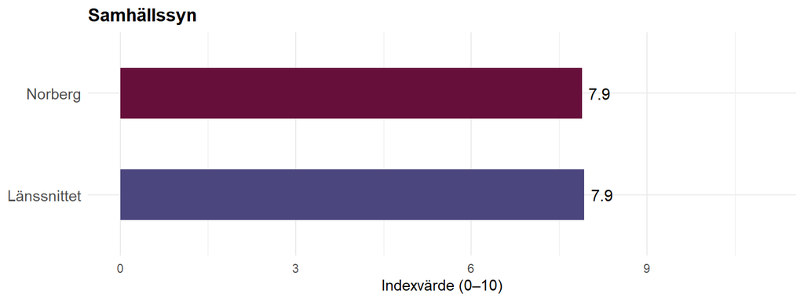

Diagram 12. Indexvärde för Samhällssyn jämfört med länssnittet.

Resultatet för Norberg visar en nivå i linje med länsgenomsnittet på området Samhällssyn (7.9 jämfört med 7.9), vilket innebär att kommunen följer det övergripande mönstret i länet.

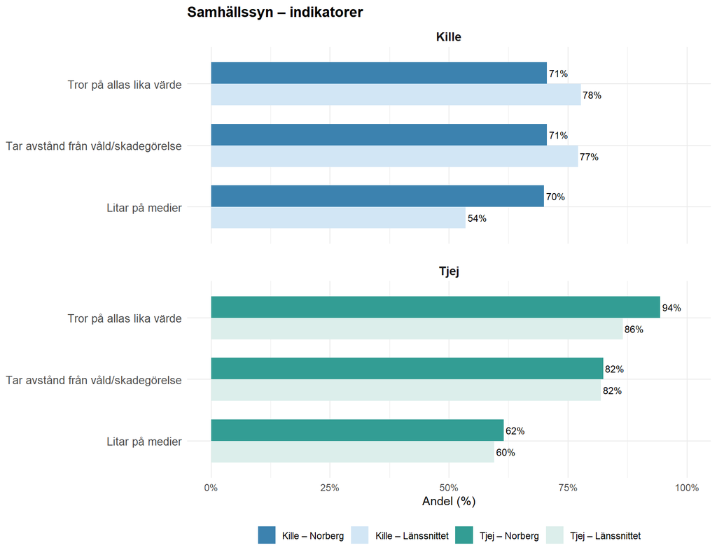

Diagram 13. Indikatorer inom Samhällssyn - andel per kön jämfört med länssnittet

Tabell 7. Indikatorer inom Samhällssyn – kommunens värde jämfört med länssnittet.

| Indikator | Kommun (%) | Länssnittet (%) | ± % | Jämfört med länet |
| --- | --- | --- | --- | --- |
| Litar på medier | 65 | 56 | 9 | ▲ Högre |
| Tar avstånd från våld/skadegörelse | 76 | 80 | -3 | ▼ Lägre |
| Tror på allas lika värde | 83 | 82 | 1 | ▲ Högre |

Norbergs samlade resultat för området Samhällssyn ligger i nivå med länet, men med flera skillnader på indikatornivå. Den tydligaste skillnaden är att killar i Norberg i högre grad litar på medier, med en andel som är 16 procentenheter högre än bland killar i länet. Samtidigt är andelen killar som tror på allas lika värde och tar avstånd från våld och skadegörelse 6–7 procentenheter lägre än i länet. Bland tjejer är andelen som tror på allas lika värde 8 procentenheter högre än i länet, medan övriga indikatorer ligger i nivå med länet. Det innebär att skillnaderna mellan tjejer och killar när det gäller synen på allas lika värde och avståndstagande från våld är större i Norberg än i länet. Med tanke på den låga svarsfrekvensen bör resultaten tolkas med försiktighet (se avsnittet Deltagande och svarsfrekvens).

## Trygghet

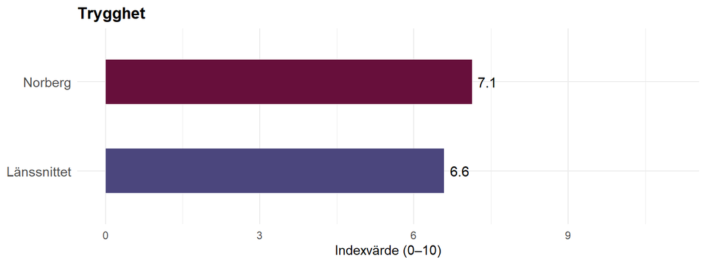

Diagram 14. Indexvärde för Trygghet jämfört med länssnittet.

Resultatet för Norberg visar en mer gynnsam nivå på området Trygghet jämfört med länsgenomsnittet (7.1 jämfört med 6.6), vilket tyder på att kommunen överlag har mer gynnsamma utfall för de indikatorer som ingår i området.

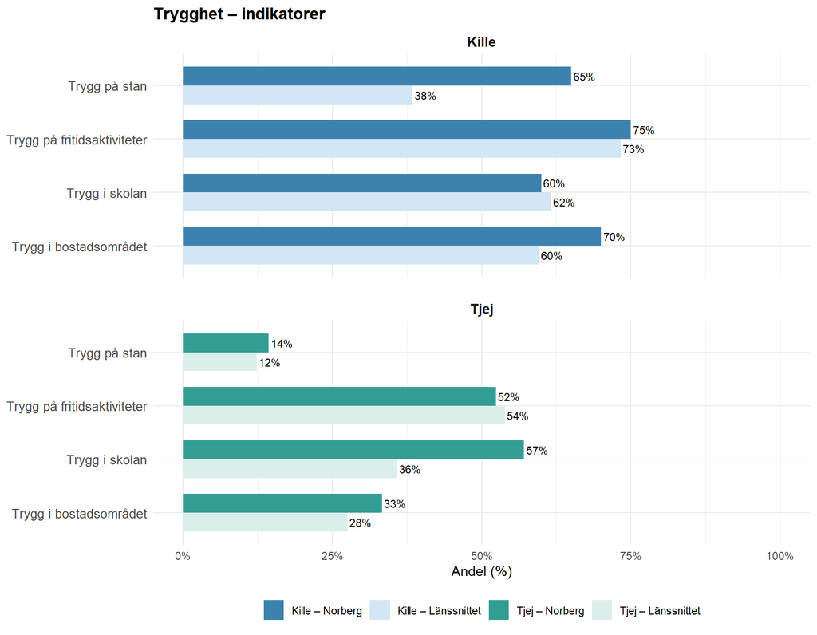

Diagram 15. Indikatorer inom Trygghet - andel per kön jämfört med länssnittet

Tabell 8. Indikatorer inom Trygghet – kommunens värde jämfört med länssnittet.

| Indikator | Kommun (%) | Länssnittet (%) | ± % | Jämfört med länet |
| --- | --- | --- | --- | --- |
| Trygg på stan | 39 | 25 | 14 | ▲ Högre |
| Trygg i skolan | 58 | 48 | 10 | ▲ Högre |
| Trygg i bostadsområdet | 51 | 43 | 8 | ▲ Högre |
| Trygg på fritidsaktiviteter | 63 | 63 | 0 | = Samma |

Det högre indexvärdet för området Trygghet drivs främst av upplevelser av trygghet på stan bland killar och trygghet i skolan bland tjejer. Andelen killar som känner sig trygga på stan är 27 procentenheter högre än bland killar i länet, och andelen som känner sig trygga i sitt bostadsområde är 10 procentenheter högre. Bland tjejer är andelen som känner sig trygga i skolan 21 procentenheter högre än i länet, medan övriga indikatorer ligger nära länets nivå. Skillnaden mellan tjejer och killar i trygghet på stan är större i Norberg än i länet, medan könsskillnaden i trygghet i skolan är mindre. Med tanke på den låga svarsfrekvensen bör resultaten tolkas med försiktighet (se avsnittet Deltagande och svarsfrekvens).

## Fritid

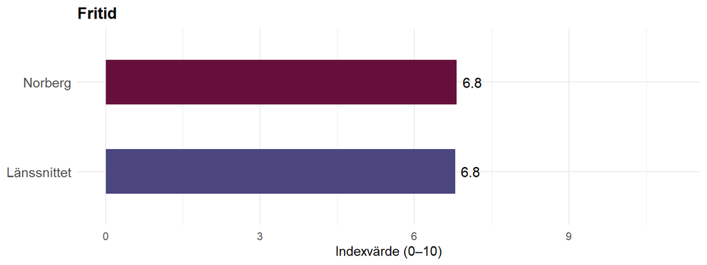

Diagram 16. Indexvärde för Fritid jämfört med länssnittet.

Resultatet för Norberg visar en nivå i linje med länsgenomsnittet på området Fritid (6.8 jämfört med 6.8), vilket innebär att kommunen följer det övergripande mönstret i länet.

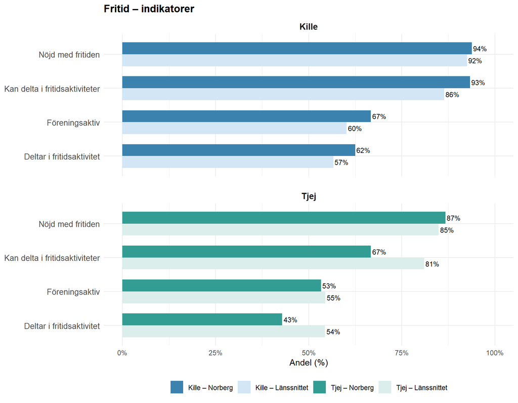

Diagram 17. Indikatorer inom Fritid - andel per kön jämfört med länssnittet

Tabell 9. Indikatorer inom Fritid – kommunens värde jämfört med länssnittet.

| Indikator | Kommun (%) | Länssnittet (%) | ± % | Jämfört med länet |
| --- | --- | --- | --- | --- |
| Kan delta i fritidsaktiviteter | 80 | 84 | -4 | ▼ Lägre |
| Föreningsaktiv | 60 | 57 | 3 | ▲ Högre |
| Deltar i fritidsaktivitet | 53 | 56 | -2 | ▼ Lägre |
| Nöjd med fritiden | 90 | 89 | 2 | ▲ Högre |

Norbergs samlade resultat för området Fritid ligger i nivå med länet, men på indikatornivå finns skillnader mellan tjejer och killar. Bland tjejer är andelen som anser att de kan delta i fritidsaktiviteter 14 procentenheter lägre än i länet, och andelen som deltar i en fritidsaktivitet är 11 procentenheter lägre. Bland killar ligger resultaten i stället något högre än i länet för samma indikatorer samt för föreningsaktivitet, med skillnader på 5–7 procentenheter. Andelen som är nöjda med sin fritid ligger i nivå med länet för både tjejer och killar. Skillnaderna mellan tjejer och killar när det gäller möjlighet att delta och faktiskt deltagande i fritidsaktiviteter är därmed större i Norberg än i länet. Med tanke på den låga svarsfrekvensen bör resultaten tolkas med försiktighet (se avsnittet Deltagande och svarsfrekvens).

## Levnadsvillkor

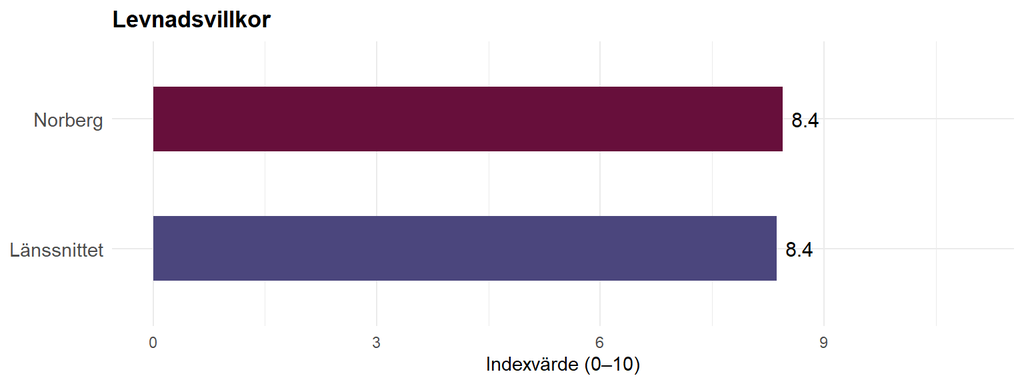

Diagram 18. Indexvärde för Levnadsvillkor jämfört med länssnittet.

Resultatet för Norberg visar en nivå i linje med länsgenomsnittet på området Levnadsvillkor (8.4 jämfört med 8.4), vilket innebär att kommunen följer det övergripande mönstret i länet.

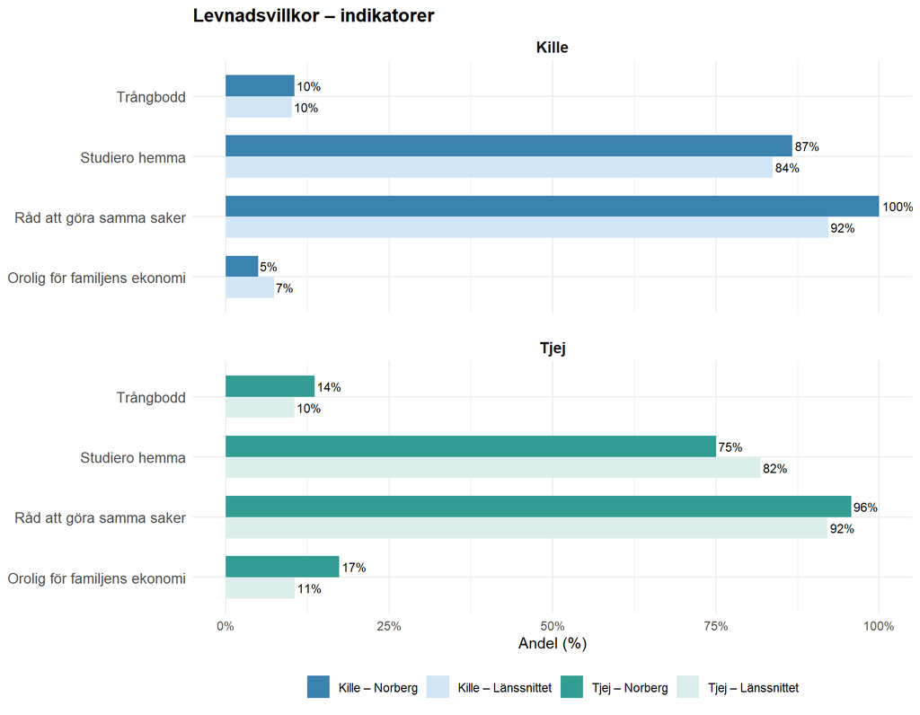

Diagram 19. Indikatorer inom Levnadsvillkor - andel per kön jämfört med länssnittet

Tabell 10. Indikatorer inom Levnadsvillkor – kommunens värde jämfört med länssnittet.

| Indikator | Kommun (%) | Länssnittet (%) | ± % | Jämfört med länet |
| --- | --- | --- | --- | --- |
| Råd att göra samma saker | 98 | 92 | 5 | ▲ Högre |
| Orolig för familjens ekonomi | 12 | 9 | 3 | ▲ Högre |
| Studiero hemma | 81 | 83 | -2 | ▼ Lägre |
| Trångbodd | 12 | 10 | 2 | ▲ Högre |

Norbergs resultat för området Levnadsvillkor ligger överlag nära länets nivå. Bland tjejer är andelen som är oroliga för familjens ekonomi 6 procentenheter högre än i länet, och andelen som har studiero hemma är 7 procentenheter lägre. Bland killar är andelen som anser att familjen har råd att göra samma saker som andra 8 procentenheter högre än i länet, medan övriga indikatorer ligger i nivå med länet. Skillnaderna mellan tjejer och killar när det gäller oro för familjens ekonomi och studiero hemma är därmed större i Norberg än i länet. Med tanke på den låga svarsfrekvensen bör resultaten tolkas med försiktighet (se avsnittet Deltagande och svarsfrekvens).

## Föräldrarelation

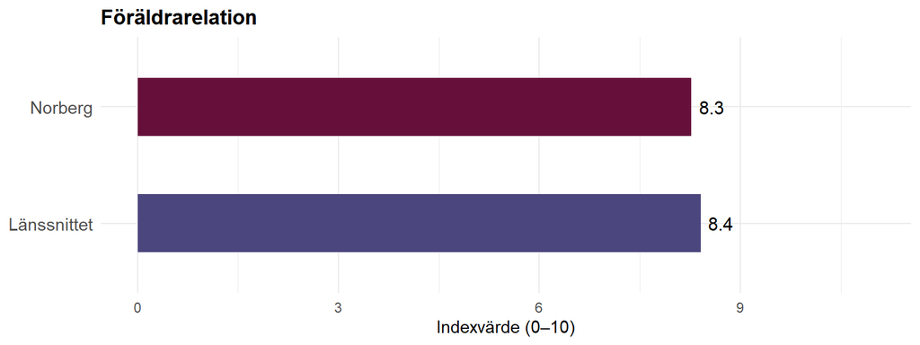

Diagram 20. Indexvärde för Föräldrarelation jämfört med länssnittet.

Resultatet för Norberg visar en nivå i linje med länsgenomsnittet på området Föräldrarelation (8.3 jämfört med 8.4), vilket innebär att kommunen följer det övergripande mönstret i länet.

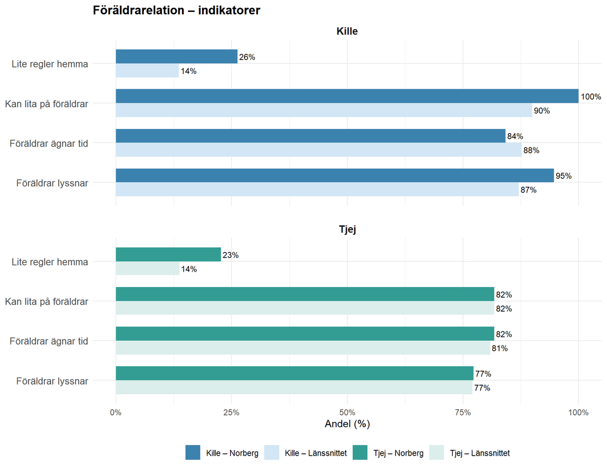

Diagram 21. Indikatorer inom Föräldrarelation - andel per kön jämfört med länssnittet

Tabell 11. Indikatorer inom Föräldrarelation – kommunens värde jämfört med länssnittet.

| Indikator | Kommun (%) | Länssnittet (%) | ± % | Jämfört med länet |
| --- | --- | --- | --- | --- |
| Lite regler hemma | 24 | 14 | 11 | ▲ Högre |
| Kan lita på föräldrar | 90 | 86 | 4 | ▲ Högre |
| Föräldrar lyssnar | 85 | 82 | 3 | ▲ Högre |
| Föräldrar ägnar tid | 83 | 84 | -1 | ▼ Lägre |

För området Föräldrarelation ligger Norbergs samlade resultat i linje med länets genomsnitt. På indikatornivå finns dock vissa skillnader. Den tydligaste skillnaden är att andelen som uppger att det finns lite regler hemma är högre än i länet bland både tjejer och killar, och bland killar är andelen nästan dubbelt så hög. Bland killar är också andelen som kan lita på sina föräldrar och upplever att föräldrarna lyssnar 8–10 procentenheter högre än i länet. Bland tjejer ligger övriga indikatorer i nivå med länet. Skillnaden mellan tjejer och killar när det gäller att kunna lita på föräldrarna och att föräldrarna lyssnar är därmed större i Norberg än i länet. Med tanke på den låga svarsfrekvensen bör resultaten tolkas med försiktighet (se avsnittet Deltagande och svarsfrekvens).

## Studiegång och resultat

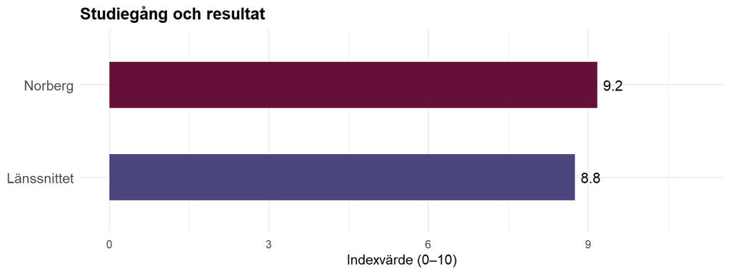

Diagram 22. Indexvärde för Studiegång och resultat jämfört med länssnittet.

Resultatet för Norberg visar en mer gynnsam nivå på området Studiegång och resultat jämfört med länsgenomsnittet (9.2 jämfört med 8.8), vilket tyder på att kommunen överlag har mer gynnsamma utfall för de indikatorer som ingår i området.

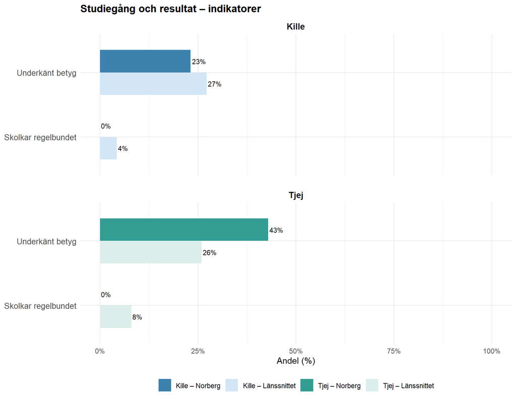

Diagram 23. Indikatorer inom Studiegång och resultat - andel per kön jämfört med länssnittet

Tabell 12. Indikatorer inom Studiegång och resultat – kommunens värde jämfört med länssnittet.

| Indikator | Kommun (%) | Länssnittet (%) | ± % | Jämfört med länet |
| --- | --- | --- | --- | --- |
| Skolkar regelbundet | 0 | 6 | -6 | ▼ Lägre |
| Underkänt betyg | 30 | 26 | 4 | ▲ Högre |

Norbergs indexvärde för området Studiegång och resultat är mer gynnsamt än länets. Det förklaras främst av att ingen av eleverna i Norberg uppger att de skolkar regelbundet. Samtidigt är andelen tjejer med underkänt betyg 17 procentenheter högre än bland tjejer i länet. Bland killar ligger andelen med underkänt betyg i stället något under länets nivå. I länet är andelen med underkänt betyg ungefär lika stor bland tjejer och killar, medan den i Norberg är betydligt högre bland tjejer. Med tanke på den låga svarsfrekvensen bör resultaten tolkas med försiktighet (se avsnittet Deltagande och svarsfrekvens).

## Skolmiljö och stöd

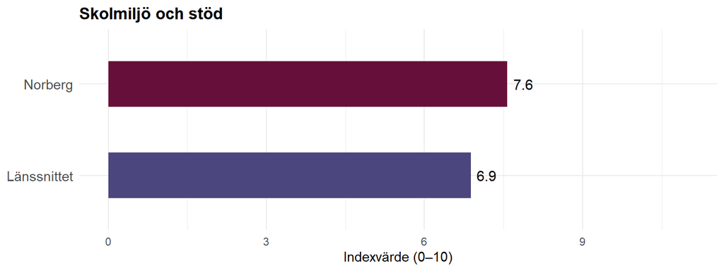

Diagram 24. Indexvärde för Skolmiljö och stöd jämfört med länssnittet.

Resultatet för Norberg visar en mer gynnsam nivå på området Skolmiljö och stöd jämfört med länsgenomsnittet (7.6 jämfört med 6.9), vilket tyder på att kommunen överlag har mer gynnsamma utfall för de indikatorer som ingår i området.

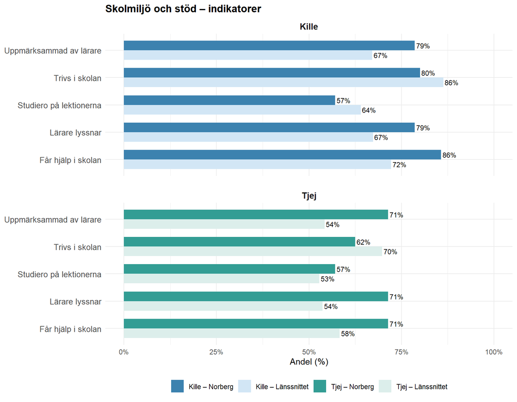

Diagram 25. Indikatorer inom Skolmiljö och stöd - andel per kön jämfört med länssnittet

Tabell 13. Indikatorer inom Skolmiljö och stöd – kommunens värde jämfört med länssnittet.

| Indikator | Kommun (%) | Länssnittet (%) | ± % | Jämfört med länet |
| --- | --- | --- | --- | --- |
| Får hjälp i skolan | 81 | 65 | 16 | ▲ Högre |
| Lärare lyssnar | 76 | 60 | 16 | ▲ Högre |
| Uppmärksammad av lärare | 76 | 60 | 16 | ▲ Högre |
| Trivs i skolan | 74 | 78 | -4 | ▼ Lägre |
| Studiero på lektionerna | 57 | 58 | -1 | ▼ Lägre |

Norberg har övergripande ett mer gynnsamt resultat inom området Skolmiljö och stöd jämfört med länet. Andelen som får hjälp i skolan, upplever att lärarna lyssnar och känner sig uppmärksammade av lärare är 16 procentenheter högre än i länet. Mönstret gäller både tjejer och killar, med skillnader på 12–17 procentenheter jämfört med länet. Samtidigt är andelen som trivs i skolan något lägre än i länet bland både tjejer och killar. Bland killar är även andelen som upplever studiero på lektionerna lägre än i länet, medan tjejernas resultat för studiero ligger nära länets nivå. Med tanke på den låga svarsfrekvensen bör resultaten tolkas med försiktighet (se avsnittet Deltagande och svarsfrekvens).

## Socialt stöd och ensamhet

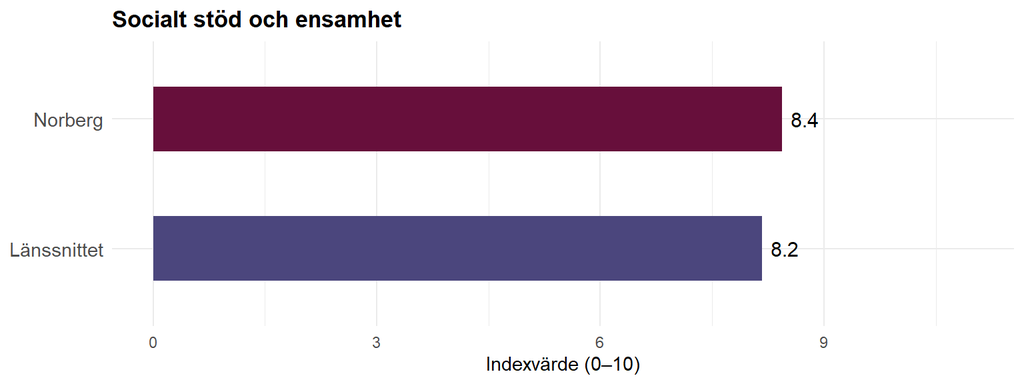

Diagram 26. Indexvärde för Socialt stöd och ensamhet jämfört med länssnittet.

Resultatet för Norberg visar en mer gynnsam nivå på området Socialt stöd och ensamhet jämfört med länsgenomsnittet (8.4 jämfört med 8.2), vilket tyder på att kommunen överlag har mer gynnsamma utfall för de indikatorer som ingår i området.

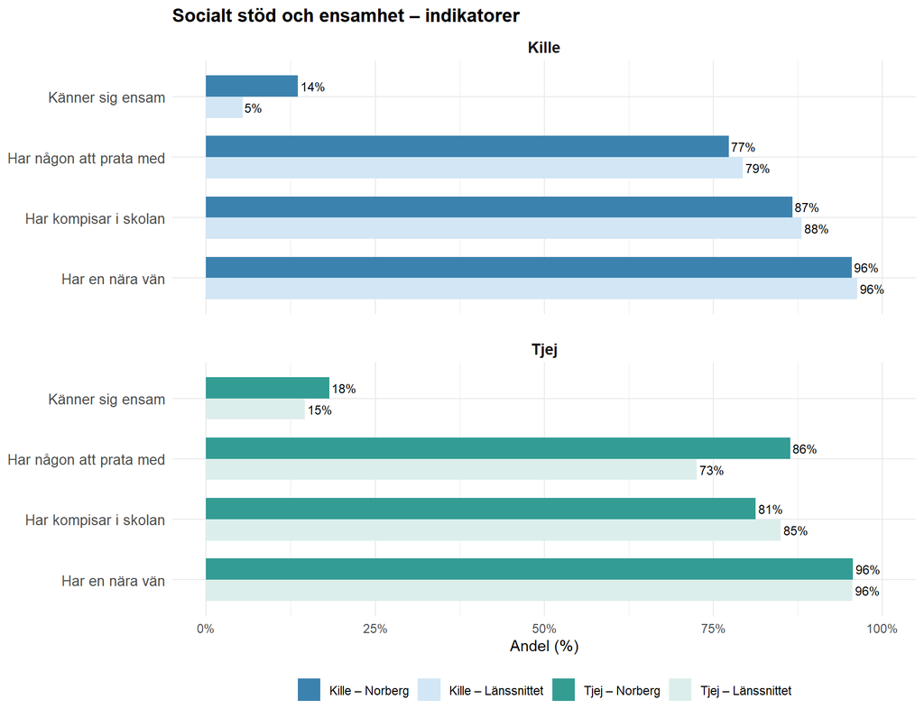

Diagram 27. Indikatorer inom Socialt stöd och ensamhet - andel per kön jämfört med länssnittet

Tabell 14. Indikatorer inom Socialt stöd och ensamhet – kommunens värde jämfört med länssnittet.

| Indikator | Kommun (%) | Länssnittet (%) | ± % | Jämfört med länet |
| --- | --- | --- | --- | --- |
| Känner sig ensam | 16 | 10 | 6 | ▲ Högre |
| Har någon att prata med | 82 | 76 | 6 | ▲ Högre |
| Har kompisar i skolan | 84 | 86 | -3 | ▼ Lägre |
| Har en nära vän | 96 | 96 | 0 | ▼ Lägre |

Norbergs samlade resultat för området Socialt stöd och ensamhet ligger något över länets nivå. Bland tjejer är andelen som har någon att prata med 13 procentenheter högre än bland tjejer i länet, medan övriga indikatorer ligger nära länets nivå. Bland killar är andelen som känner sig ensamma nästan tre gånger så hög som bland killar i länet, medan andelen som har någon att prata med, kompisar i skolan och en nära vän ligger i nivå med länet. Med tanke på den låga svarsfrekvensen bör resultaten tolkas med försiktighet (se avsnittet Deltagande och svarsfrekvens).

## Livsstil

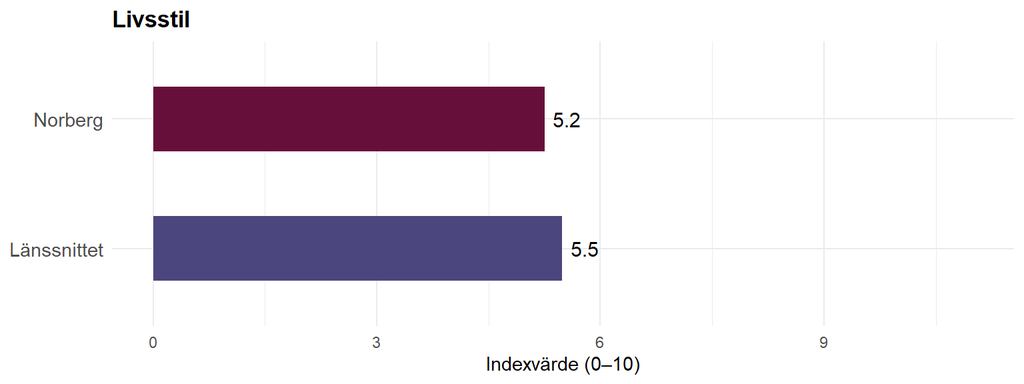

Diagram 29. Indexvärde för Livsstil jämfört med länssnittet.

Resultatet för Norberg visar en mindre gynnsam nivå på området Livsstil jämfört med länsgenomsnittet (5.2 jämfört med 5.5), vilket tyder på att kommunen överlag har mindre gynnsamma utfall för de indikatorer som ingår i området.

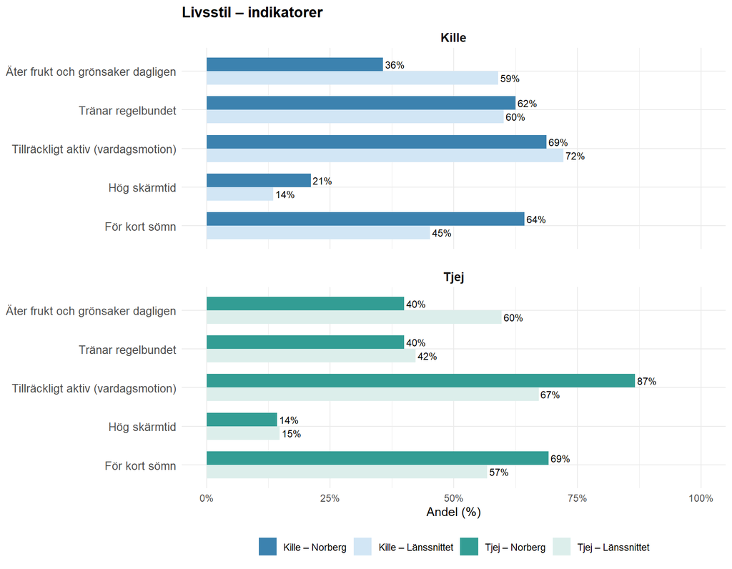

Diagram 30. Indikatorer inom Livsstil - andel per kön jämfört med länssnittet

Tabell 15. Indikatorer inom Livsstil – kommunens värde jämfört med länssnittet.

| Indikator | Kommun (%) | Länssnittet (%) | ± % | Jämfört med länet |
| --- | --- | --- | --- | --- |
| Äter frukt och grönsaker dagligen | 38 | 59 | -21 | ▼ Lägre |
| För kort sömn | 67 | 51 | 16 | ▲ Högre |
| Tillräckligt aktiv (vardagsmotion) | 77 | 70 | 8 | ▲ Högre |
| Hög skärmtid | 18 | 14 | 3 | ▲ Högre |
| Tränar regelbundet | 52 | 51 | 1 | ▲ Högre |

För området Livsstil har Norberg ett mindre gynnsamt resultat än länet, vilket drivs främst av två indikatorer: att äta frukt och grönsaker dagligen och att få tillräckligt med sömn. Andelen som äter frukt och grönsaker dagligen är 20–23 procentenheter lägre än i länet bland både tjejer och killar. Andelen med för kort sömn är 19 procentenheter högre än i länet bland killar och 12 procentenheter högre bland tjejer. Bland killar är även hög skärmtid något vanligare än i länet. Samtidigt är andelen tjejer som är tillräckligt fysiskt aktiva i vardagen 20 procentenheter högre än bland tjejer i länet, medan killarnas resultat för fysisk aktivitet och träning ligger nära länets nivå. Med tanke på den låga svarsfrekvensen bör resultaten tolkas med försiktighet (se avsnittet Deltagande och svarsfrekvens).